# Lab 5: Testing Covariance Matrices and MANOVA

Reesa John

# The Data

Today’s dataset is taken from a survey of 84 Cal Poly students. The students were asked how many speeding tickets they had received in their lives, the fastest speed they had ever driven, and the number of hours per week they spend studying.

Run the code below to load the data.

```r
dat <- read.csv("https://www.dropbox.com/s/vb85kbwqv5o8lia/Subset%20S2010data.TXT?dl=1", sep = "")
```

## Checking the data ahead of time

Take a look at the data, using whatever R functions you prefer. Do you see any possible issues? Why might these present a problem to our analyses?

```r
summary(dat)
```

```
##      Gender      Year      StudyHours    SpeedTickets    FastDrive
##  Min.   :0.000   F :32   Min.   : 3.0   Min.   :0.00   Min.   : 70.0
##  1st Qu.:0.000   G : 1   1st Qu.:10.0   1st Qu.:0.00   1st Qu.: 93.8
##  Median :0.000   J :18   Median :19.5   Median :0.00   Median :100.0
##  Mean   :0.439   SE:14   Mean   :18.0   Mean   :0.71   Mean   :106.4
##  3rd Qu.:1.000   SO:19   3rd Qu.:25.0   3rd Qu.:1.00   3rd Qu.:120.0
##  Max.   :1.000           Max.   :40.0   Max.   :5.00   Max.   :160.0
##  NA's   :2
```

```r
head(dat)
```

```
##   Gender Year StudyHours SpeedTickets FastDrive
## 1     NA   SE       20.0            3       100
## 2      1    F       25.0            1       120
## 3      0    F       12.5            0       110
## 4      1    F       15.0            1        95
## 5      1    F       20.0            0        80
## 6      1    F       15.0            2        95
```

```
Gender is not a factor, and there seems to be a few NA's scattered among columns. In addition, there is only one graduate student, so we can't say anything about him, so if we do anything relating to school year, we should take the graduate student out of the equation.
```

Modify the code below to drop the problematic rows of data.

```r
dat <- dat %>%
  na.omit()%>%
  mutate(
    Gender = as.factor(Gender),
    Year = as.factor(Year)
  )%>%
  filter(Year!="G")

summary(dat)
```

```
##  Gender Year      StudyHours    SpeedTickets    FastDrive
##  0:46   F :32   Min.   : 3.0   Min.   :0.00   Min.   : 70
##  1:35   G : 0   1st Qu.:10.0   1st Qu.:0.00   1st Qu.: 95
##         J :18   Median :17.5   Median :0.00   Median :100
##         SE:13   Mean   :17.8   Mean   :0.65   Mean   :106
##         SO:18   3rd Qu.:25.0   3rd Qu.:1.00   3rd Qu.:120
##                 Max.   :40.0   Max.   :5.00   Max.   :160
```

# Box’s M-Test

Consider testing the hypothesis “Male-idenfiying students are equally as responsible as female-identifying students.”

Perform the appropriate test in R for this hypothesis.

```r
hotDat <- dat %>% select(-Year)

htest <- hotelling.test(. ~Gender, hotDat)
htest
```

```
## Test stat:  6.7243
## Numerator df:  3
## Denominator df:  77
## P-value:  0.0004336
```

[output not shown]

The test above relied on the assumption that the covariance matrices were the same for all populations. Express this assumption as a null hypothesis, in both symbols and words.

```
Our null hypothesis is that the covariance matrices for study hours, speeding tickets, and fast driving tickets are the same for both male and female identifying  populations.
```

Calculate the $M$ statistic for this test. What do you expect it to be under the null? What does the actual value suggest to you?

```r
gen0 <- hotDat %>%
  filter(Gender == 0)%>%
  dplyr::select(-Gender)%>%
  as.matrix()

gen1 <- hotDat %>%
  filter(Gender == 1)%>%
  dplyr::select(-Gender)%>%
  as.matrix()


n1 = 46 #0
n2 = 35 #1

S1 = cov(gen0)
S2 = cov(gen1)

Sp = ((n1-1)*(S1))+((n2-1)*(S2))/(n1+n2-2)

M <- (((det(S1))^((n1-1)/2))*((det(S2))^((n2-1)/2)))/((det(Sp))^((n1 + n2 -2)/2))

M
```

```
## [1] 0
```

[output not shown]

Run the following code to perform the full hypothesis test. What do you conclude?

```r
#install.packages("heplots")
library(heplots)

boxM(cbind(StudyHours, SpeedTickets, FastDrive) ~ factor(Year), data = dat)
```

```
##
##  Box's M-test for Homogeneity of Covariance Matrices
##
## data:  Y
## Chi-Sq (approx.) = 40, df = 20, p-value = 7e-04
```

[output not shown]

# Testing Covariance Matrices

Suppose we wish further understand the relationship between max driving speed, number of speeding tickets, and hours studied.

## A specific null

Run the following code, which will show you $\Sigma_0$, a proposed covariance matrix between these three variables.

```r
sigma_0 <- cbind(c(75, 0, -4), c(0, 1, 6), c(-4, 6, 366))
sigma_0
```

```
##      [,1] [,2] [,3]
## [1,]   75    0   -4
## [2,]    0    1    6
## [3,]   -4    6  366
```

Convert this covariance matrix to a correlation matrix. In plain English, what claim is being made about these three variables?

```r
D <- sqrt(diag(sigma_0))
D <- diag(D,nrow = 3)
invD = solve(D)

corr = invD %*% sigma_0 %*% invD
corr
```

```
##         [,1]  [,2]    [,3]
## [1,]  1.0000 0.000 -0.0241
## [2,]  0.0000 1.000  0.3136
## [3,] -0.0241 0.314  1.0000
```

[output not shown]

Using R (not by hand!) calculate a test statistic for testing a null hypothesis of $H_0: \Sigma = \Sigma_0$. What does this suggest to you?

```r
allDat <- dat %>%
  dplyr::select(-Gender,-Year)%>%
  as.matrix()

actCov <- cov(allDat)

det(sigma_0)/det(actCov)
```

```
## [1] 1.01
```

```
Since the value of the test statistic is so close to one, that means that the sample covariance of the entire data set is very close to the covariance suggested to us. This suggests to us that there is a good change the suggested covariance matrix is the population covariance matrix.
```

## Independence

Is it reasonable to think that there is a no relationship between the hours studied, speeding tickets, and driving fast? Calculate an appropriate test statistic and make an argument to address this question.

```r
sigma_none <- cbind(c(77.899, 0, 0), c(0, 0.954, 0), c(0, 0, 368.77))

det(sigma_none)/det(actCov)
```

```
## [1] 1.12
```

[output not shown]

## Subvectors

Is it reasonable to think that hours of study is independent of erratic driving (speeding tickets and fast driving)? Calculate an appropriate test statistic and make an argument to address this question.

```r
sigma_other <- cbind(c(77.899, 0, 0), c(0, 0.954, 6.172), c(0, 6.172, 368.77))

det(sigma_none)/det(actCov)
```

```
## [1] 1.12
```

[output not shown]

# One-Way MANOVA

Consider the following statement:

“Cal Poly students are equally responsible - as measured by their driving speed, speeding tickets, and study hours - in every year of schooling.”

First, use and duplicate the following code to look at the data. Do the plots seem to support this statement?

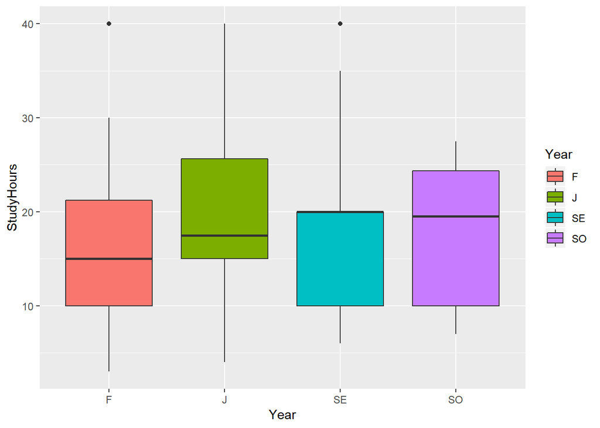

```r
ggplot(dat, aes(x = Year, y = StudyHours, fill = Year)) + geom_boxplot()
```

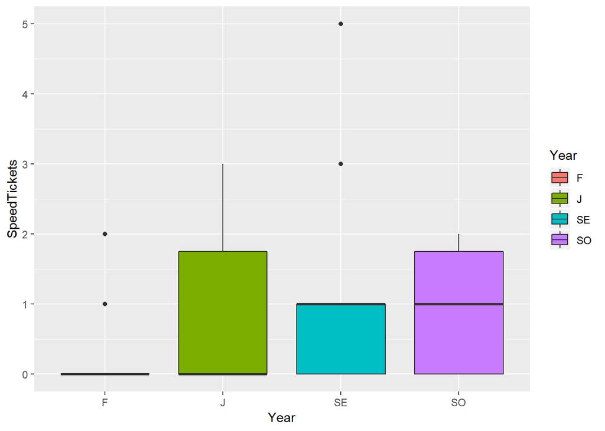

```r
ggplot(dat, aes(x = Year, y = SpeedTickets, fill = Year)) + geom_boxplot()
```

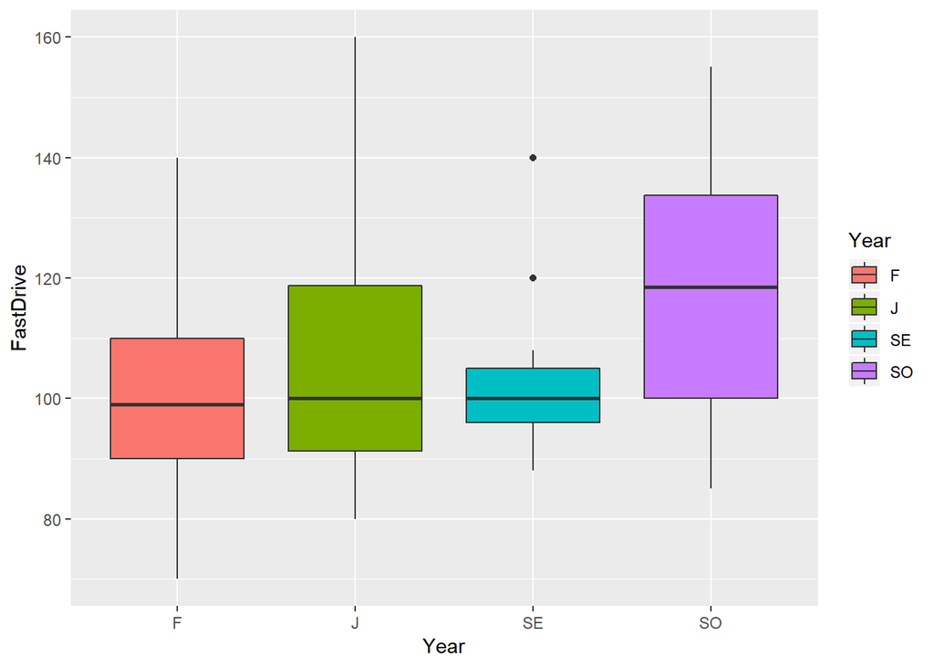

[output not shown]

```r
ggplot(dat, aes(x = Year, y = FastDrive, fill = Year)) + geom_boxplot()
```

Next, perform an appropriate test to address the statement. Make sure to state your null and alternate hypothesis, and to perform an appropriate adjustment of the data before using the `manova()` function in R.

```r
mv.mod <- manova(cbind(StudyHours,SpeedTickets ,FastDrive) ~ factor(Year), data = dat)
mv.sum <- summary(mv.mod, test = "Wilks")

H = round(mv.sum$SS[[1]], 0)
E = round(mv.sum$SS[[2]], 0)

H
```

```
##              StudyHours SpeedTickets FastDrive
## StudyHours          133           34       137
## SpeedTickets         34           14       109
## FastDrive           137          109      3211
```

```r
E
```

```
##              StudyHours SpeedTickets FastDrive
## StudyHours         6099          -51      -400
## SpeedTickets        -51           63       385
## FastDrive          -400          385     26291
```

```r
mv.sum
```

```
##              Df Wilks approx F num Df den Df Pr(>F)
## factor(Year)  3 0.725     2.87      9    183 0.0034 **
## Residuals    77
## ---
## Signif. codes:  0 '***' 0.001 '**' 0.01 '*' 0.05 '.' 0.1 ' ' 1
```

```
H0 = The means for study hours, speeding tickets, and fast driving are the same across all years.
Ha = The means for study hours, speeding tickets, and fast driving are not the same across all years.

The p-value 0.0034 which is less than the alpha of 0.05. Thus we reject H0 in favor of Ha. There is a significant difference means between years.
```

# Two-Way MANOVA

Now consider a different statement:

“Cal Poly students are equally responsible - as measured by their driving speed, speeding tickets, and study hours - in every year of schooling. Furthermore, male and female identifying students are also equally responsible, in terms of those three measurements.”

Perform appropriate test(s) to address this statement.

```r
#only valid with pool; manova
mv.mod <- manova(cbind(StudyHours,SpeedTickets ,FastDrive) ~ factor(Year)*factor(Gender), data = dat)
mv.sum <- summary(mv.mod, test = "Wilks")

HA = round(mv.sum$SS[[1]], 0)
HB = round(mv.sum$SS[[2]], 0)
HAB = round(mv.sum$SS[[3]], 0)
E = round(mv.sum$SS[[4]], 0)

mv.sum
```

```
##                             Df Wilks approx F num Df den Df Pr(>F)
## factor(Year)                 3 0.701     3.02      9    173 0.0023 **
## factor(Gender)               1 0.759     7.50      3     71 0.0002 ***
## factor(Year):factor(Gender)  3 0.822     1.61      9    173 0.1163
## Residuals                   73
## ---
## Signif. codes:  0 '***' 0.001 '**' 0.01 '*' 0.05 '.' 0.1 ' ' 1
```

[output not shown]

What are the assumptions about the data for the test you performed?

```
We are assuming that there are equal covariances among the groups. In order to test this, we need to do a Box's M test. We all need to assume that the groups are multivariate normal, and all randomly sampled.
```